# EBENEZER MARADESA

## Project 1

## Investigate Trends of Patients Who Do or Do Not Show Up for Medical Appointments

### DATASET: `noshowappointments-kagglev2-may-2016.csv`

- Introduction
- Data Wrangling
- Exploratory Data Analysis
- Conclusions

# Introduction

Not everyone keeps their medical appointments, and this depends on several factors. This analysis hopes to explore various factors that might determine whether or not a patient keeps their medical appointments, according the the variable present in the dataset above.

### Questions

The following questions will be explored:

1. Which gender is more likely to keep appointments?
2. Are people from a particular neighborhood more likely to keep appointments?
3. How does age affect the likelihood of a patient keeping their appointments?
4. How does the time lag between scheduling and actual appointment day affect appointment-keeping?
5. Does disability prevent a patient from keeping appointments, and does this depend on number of disabilities?
6. Does the scholarship(a form of health insurance) enable people keep their appointments more?
7. Does Hypertension make a patient keener to keep appointments?
8. How do Diabetics fare with appointments?
9. Does Alcoholism interfere with a patient's appointment-keeping?
10. Are SMS reminders effective?

Before getting started, all needed libraries will be imported.

1. Pandas for dataframe operations
2. Numpy as needed for supporting Pandas
3. Datetime to correctly format columns holding dates
4. Matplotlib for plotting
5. Seaborn for styling plots
6. Gridspec to efficiently organize plots into grids.

```python
import pandas as pd
import numpy as np
from datetime import datetime as dt
import matplotlib.pyplot as plt
import seaborn as sns
from matplotlib.gridspec import GridSpec
sns.set_style('darkgrid')
%matplotlib inline
```

# Wrangling

### General Information

```python
# reading in the file and priting the first few lines to get a 'feel' of the data
df = pd.read_csv('noshowappointments-kagglev2-may-2016.csv')
df.head()
```

|  | PatientId | AppointmentID | Gender | ScheduledDay | AppointmentDay | Age | Neighbourhood | Scholarship | Hipertension | Diabetes | Alcoholism | Handcap | SMS_received | No-show |
| --- | --- | --- | --- | --- | --- | --- | --- | --- | --- | --- | --- | --- | --- | --- |
| 0 | 2.987250e+13 | 5642903 | F | 2016-04-29T18:38:08Z | 2016-04-29T00:00:00Z | 62 | JARDIM DA PENHA | 0 | 1 | 0 | 0 | 0 | 0 | No |
| 1 | 5.589978e+14 | 5642503 | M | 2016-04-29T16:08:27Z | 2016-04-29T00:00:00Z | 56 | JARDIM DA PENHA | 0 | 0 | 0 | 0 | 0 | 0 | No |
| 2 | 4.262962e+12 | 5642549 | F | 2016-04-29T16:19:04Z | 2016-04-29T00:00:00Z | 62 | MATA DA PRAIA | 0 | 0 | 0 | 0 | 0 | 0 | No |
| 3 | 8.679512e+11 | 5642828 | F | 2016-04-29T17:29:31Z | 2016-04-29T00:00:00Z | 8 | PONTAL DE CAMBURI | 0 | 0 | 0 | 0 | 0 | 0 | No |
| 4 | 8.841186e+12 | 5642494 | F | 2016-04-29T16:07:23Z | 2016-04-29T00:00:00Z | 56 | JARDIM DA PENHA | 0 | 1 | 1 | 0 | 0 | 0 | No |

```python
# Information on shape of dataframe, missing data, datatypes in columns
df.info()
```

```
<class 'pandas.core.frame.DataFrame'>
RangeIndex: 110527 entries, 0 to 110526
Data columns (total 14 columns):
 #   Column          Non-Null Count   Dtype
---  ------          --------------   -----
 0   PatientId       110527 non-null  float64
 1   AppointmentID   110527 non-null  int64
 2   Gender          110527 non-null  object
 3   ScheduledDay    110527 non-null  object
 4   AppointmentDay  110527 non-null  object
 5   Age             110527 non-null  int64
 6   Neighbourhood   110527 non-null  object
 7   Scholarship     110527 non-null  int64
 8   Hipertension    110527 non-null  int64
 9   Diabetes        110527 non-null  int64
 10  Alcoholism      110527 non-null  int64
 11  Handcap         110527 non-null  int64
 12  SMS_received    110527 non-null  int64
 13  No-show         110527 non-null  object
dtypes: float64(1), int64(8), object(5)
memory usage: 11.8+ MB
```

### Summary of Dataset

The dataset contains details of patients who did or did not show up for their appointments.

- PatientId: ID of the patient
- AppointmentID: Unique ID for appointments.
- Gender: M or F
- ScheduledDay: The day the appointment was scheduled.
- AppointmentDay: The day of the appointment.
- Age: Of Patient
- Neighborhood: Where patient resides.
- Scholarship: Whether or not the patient is enrolled in the welfare program.
- Hypertension: Is patient hypertensive or not?
- Diabetes: Diabetic or not?
- Alcoholism: alcoholic or not?
- Handicap: Handicapped or not?
- SMS_received: did patient receive SMS reminder for appointment?
- No-show: Did the patient show up? Yes means it's a no-show(i.e., patient didn't show up).

There appears to be no missing values anywhere in the dataset, therefore, there is no need to fill in any mising values.

### Renaming Columns

> For ease of manipulating later, columns will be renames to convert to all lowercase and replace spaces with underscores.

> Columns like `PatientId` and `SchduledDay` can be better read as `patient_id` and `scheduled_day` respectively.

> Some colum names are misspelt, `Hipertension` and `Handcap`.

```python
# Performing the first operation

df.rename(columns= lambda x:x.strip().lower().replace(' ', '_'), inplace=True)
```

```python
# The next two operations to process column names

df.rename(columns={'patientid':'patient_id',
                    'appointmentid':'appoinment_id',
                    'hipertension':'hypertension',
                    'handcap':'handicap',
                    'no-show':'no_show',
                    'scheduledday': 'scheduled_day',
                    'appointmentday': 'appointment_day'
                    }, inplace=True)
```

### Dealing with Data Types

> Since `patient_id`'s are unique, they best be `int` rather than `float`

> `scheduled_day` and `appointment_day` columns should be converted to regular datetime objects. The dates will be extracted and the time fragments discarded, as they will not be relevant. Afterall, an observation of the `appointment_day` column shows all the time fragments as 00:00:00

```python
# converting patient_id's to int
df.patient_id = df.patient_id.astype(int)
```

```python
# dealing with datetime
df.scheduled_day = df.scheduled_day.apply(lambda x: dt.strptime(x.split('T')[0], '%Y-%m-%d'))
df.appointment_day = df.appointment_day.apply(lambda x: dt.strptime(x.split('T')[0], '%Y-%m-%d'))
```

```python
# confirm changes
df.head()
```

|  | patient_id | appoinment_id | gender | scheduled_day | appointment_day | age | neighbourhood | scholarship | hypertension | diabetes | alcoholism | handicap | sms_received | no_show |
| --- | --- | --- | --- | --- | --- | --- | --- | --- | --- | --- | --- | --- | --- | --- |
| 0 | 29872499824296 | 5642903 | F | 2016-04-29 | 2016-04-29 | 62 | JARDIM DA PENHA | 0 | 1 | 0 | 0 | 0 | 0 | No |
| 1 | 558997776694438 | 5642503 | M | 2016-04-29 | 2016-04-29 | 56 | JARDIM DA PENHA | 0 | 0 | 0 | 0 | 0 | 0 | No |
| 2 | 4262962299951 | 5642549 | F | 2016-04-29 | 2016-04-29 | 62 | MATA DA PRAIA | 0 | 0 | 0 | 0 | 0 | 0 | No |
| 3 | 867951213174 | 5642828 | F | 2016-04-29 | 2016-04-29 | 8 | PONTAL DE CAMBURI | 0 | 0 | 0 | 0 | 0 | 0 | No |
| 4 | 8841186448183 | 5642494 | F | 2016-04-29 | 2016-04-29 | 56 | JARDIM DA PENHA | 0 | 1 | 1 | 0 | 0 | 0 | No |

```python
df.info()
```

```
<class 'pandas.core.frame.DataFrame'>
RangeIndex: 110527 entries, 0 to 110526
Data columns (total 14 columns):
 #   Column           Non-Null Count   Dtype
---  ------           --------------   -----
 0   patient_id       110527 non-null  int64
 1   appoinment_id    110527 non-null  int64
 2   gender           110527 non-null  object
 3   scheduled_day    110527 non-null  datetime64[ns]
 4   appointment_day  110527 non-null  datetime64[ns]
 5   age              110527 non-null  int64
 6   neighbourhood    110527 non-null  object
 7   scholarship      110527 non-null  int64
 8   hypertension     110527 non-null  int64
 9   diabetes         110527 non-null  int64
 10  alcoholism       110527 non-null  int64
 11  handicap         110527 non-null  int64
 12  sms_received     110527 non-null  int64
 13  no_show          110527 non-null  object
dtypes: datetime64[ns](2), int64(9), object(3)
memory usage: 11.8+ MB
```

```python
# save cleaned dataset
# df.to_csv('no_show_appoints_cleaned.csv', index=False)
# commented out the saving to prevent accidentally overwriting
```

## Exploratory Data Analysis

A closer look will be taken at the dataset before tackling specific questions

```python
df.nunique()
```

```
patient_id          62299
appoinment_id      110527
gender                  2
scheduled_day         111
appointment_day        27
age                   104
neighbourhood          81
scholarship             2
hypertension            2
diabetes                2
alcoholism              2
handicap                5
sms_received            2
no_show                 2
dtype: int64
```

At this stage, observation of the unique values in each column opened up more questions, and these have been updated in the Introduction.

### Q1. Which gender is more likely to keep appointments?

> **TODO**:
> - Get the dataframes for each gender
> - Count number in each gender dataframe of patients who show up
> - Plot in pie charts

```python
male_df = df.query("gender=='M'")
female_df = df.query("gender=='F'")
len(male_df), len(female_df)
```

```
(38687, 71840)
```

There is a huge discrepancy between the number of males and females in the dataset, therefore, a pie chart will be needed to get relative values.

```python
male_shows = df['no_show'][df['gender']=='M']
no_show_males = len(male_shows[male_shows=='Yes'])
show_males = len(male_shows) - no_show_males    # males who show up for their appointments

female_shows = (df['no_show'][df['gender']=='F'])
no_show_females = len(female_shows[female_shows=='Yes'])
show_females = len(female_shows) - no_show_females  # females who show up for their appointments
```

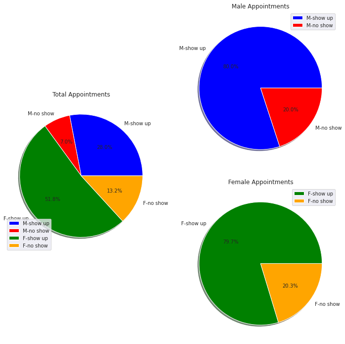

```python
# Visualize in pie charts.
# First contains plot with total appointments, while the others are gender specific for better insight

fig = plt.figure(figsize=(10,10))
gs = GridSpec(nrows=2, ncols=2)

ax = fig.add_subplot(gs[:,0])
ax.pie([show_males, no_show_males, show_females, no_show_females],
        labels=['M-show up', 'M-no show', 'F-show up', 'F-no show'],
        colors=['blue', 'red', 'green', 'orange'],
        shadow=True, autopct='%1.1f%%')
ax.legend()
ax.set_title("Total Appointments")

ax = fig.add_subplot(gs[0,1])
ax.pie([show_males, no_show_males],
        labels=['M-show up', 'M-no show'],
        colors=['blue', 'red'],
        shadow=True, autopct='%1.1f%%')
ax.legend()
ax.set_title("Male Appointments")

ax = fig.add_subplot(gs[1,1])
ax.pie([show_females, no_show_females],
        labels=['F-show up', 'F-no show'],
        colors=['green', 'orange'],
        shadow=True, autopct='%1.1f%%')
ax.legend()
ax.set_title("Female Appointments")

fig.tight_layout()
```

The visualization shows that though women, indeed, make more doctor's appointments, they are not more likely to keep them than men. The percentage of men who show up is **80%**, while that of women who show up is **79.7%**. Therefore, from this dataset, it seems both genders are equally likely to show up for their appointments.

### Q2. Are people from a particular neighborhood more likely to keep appointments?

> **TODO**
> - Get a list of unique neighborhoods
> - Loop through the list to make a new dataframe for neighborhoods
> - Visualize
> - Save new dataset to a separate csv file

```python
# unique neighborhoods
neighs = df.neighbourhood.unique()
len(neighs)
```

```
81
```

```python
# neigh_props_df = pd.DataFrame(columns=['neighborhood', 'total_appts', 'kept_appts', 'missed_appts', '%_kept'])
temp = []
for neigh in neighs:
    neigh_df = df[df.neighbourhood==neigh]  # dataframe of appointments pertaining to a particular neighborhood
    df_kept = neigh_df[neigh_df.no_show=='No']  # dataframe appointments from that neighborhood that were kept
    neigh_total = len(neigh_df)
    neigh_kept = len(df_kept)
    neigh_missed = neigh_total - neigh_kept
    neigh_percent = round(((neigh_kept/neigh_total) * 100) ,2)

    temp.append((neigh, neigh_total, neigh_kept, neigh_missed, neigh_percent))

neigh_props_df = pd.DataFrame(temp, columns=('neighborhood', 'total_appts', 'kept_appts', 'missed_appts', '%_kept'))
```

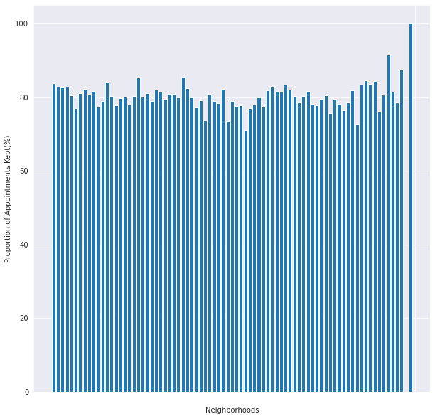

```python
fig = plt.figure(figsize=(10,10))
gs = GridSpec(nrows=2, ncols=2)

ax=fig.add_subplot(gs[:])
ax.bar(neigh_props_df['neighborhood'], neigh_props_df['%_kept'])
ax.set_xlabel("Neighborhoods")
ax.set_ylabel("Proportion of Appointments Kept(%)")
ax.set_title("Percentage of Appointments Kept from Each Neighborhood.")
ax.set_xticks(" ")
```

While this gives an idea of the proportions of appointments kept by neighborhoods, it is not very helpful as to what happens within specific neighborhoods. However, this newly fashioned dataframe does give some interesting insights by sorting variously, in ascending or descending order of total_appts or %_kept. A specific neighborhood can also be indexed to see its performance.

```python
neigh_props_df.sort_values(by='%_kept', ascending=False)
```

|  | neighborhood | total_appts | kept_appts | missed_appts | %_kept |
| --- | --- | --- | --- | --- | --- |
| 80 | PARQUE INDUSTRIAL | 1 | 1 | 0 | 100.00 |
| 75 | ILHA DO BOI | 35 | 32 | 3 | 91.43 |
| 78 | AEROPORTO | 8 | 7 | 1 | 87.50 |
| 29 | MÁRIO CYPRESTE | 371 | 317 | 54 | 85.44 |
| 19 | SOLON BORGES | 469 | 400 | 69 | 85.29 |
| ... | ... | ... | ... | ... | ... |
| 34 | ITARARÉ | 3514 | 2591 | 923 | 73.73 |
| 39 | SANTA CLARA | 506 | 372 | 134 | 73.52 |
| 68 | SANTA CECÍLIA | 448 | 325 | 123 | 72.54 |
| 43 | SANTOS DUMONT | 1276 | 907 | 369 | 71.08 |
| 79 | ILHAS OCEÂNICAS DE TRINDADE | 2 | 0 | 2 | 0.00 |

81 rows × 5 columns

```python
# Save the new neighborhoods dataset for furhter exploration as might be necessary
# neigh_props_df.to_csv('appointment_proportions_by_neighbourhood.csv')
# comment out the saving to prevent accidental overwriting
```

### Q3. How does age affect the likelihood of a patient keeping their appointments?

> **TODO**
> - Get a list of unique ages
> - Loop through the list to get proportions of members of each age that kept their appointments
> - Make a scatter plot

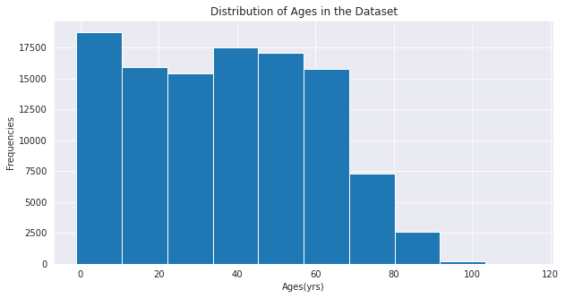

```python
# to begin, a visualization of age distribution could be useful
fig = plt.figure(figsize=(10,5))
ax = fig.add_subplot()

ax.hist(df.age)
ax.set_xlabel('Ages(yrs)')
ax.set_ylabel('Frequencies')
ax.set_title('Distribution of Ages in the Dataset')
```

```python
df.age.nunique(), df.age.value_counts()
```

```
(104,
  0      3539
  1      2273
  52     1746
  49     1652
  53     1651
         ...
  115       5
  100       4
  102       2
  99        1
 -1         1
 Name: age, Length: 104, dtype: int64)
```

```python
ages = df.age.unique()
ages
```

```
array([ 62,  56,   8,  76,  23,  39,  21,  19,  30,  29,  22,  28,  54,
        15,  50,  40,  46,   4,  13,  65,  45,  51,  32,  12,  61,  38,
        79,  18,  63,  64,  85,  59,  55,  71,  49,  78,  31,  58,  27,
         6,   2,  11,   7,   0,   3,   1,  69,  68,  60,  67,  36,  10,
        35,  20,  26,  34,  33,  16,  42,   5,  47,  17,  41,  44,  37,
        24,  66,  77,  81,  70,  53,  75,  73,  52,  74,  43,  89,  57,
        14,   9,  48,  83,  72,  25,  80,  87,  88,  84,  82,  90,  94,
        86,  91,  98,  92,  96,  93,  95,  97, 102, 115, 100,  99,  -1])
```

```python
age_props = []  # list to hold proportions of appointments kept by age
for age in ages:
    age_df = df[df.age == age]
    age_show = age_df[age_df.no_show == 'No']
    age_props.append(round(((len(age_show)/len(age_df))*100),2))
    # proportion of patients of the particular age who show up

print(age_props)
```

[output not shown]

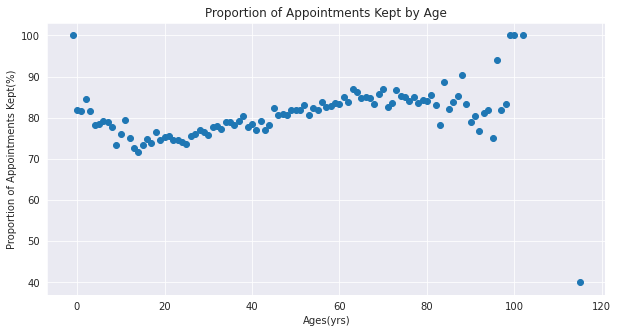

```python
fig = plt.figure(figsize=(10,5))
ax = fig.add_subplot()

ax.scatter(ages, age_props)
ax.set_xlabel('Ages(yrs)')
ax.set_ylabel('Proportion of Appointments Kept(%)')
ax.set_title('Proportion of Appointments Kept by Age')
```

From this scatter plot, it appears that propoertions of appointments kept is initially high at infancy, drops gradually till the late teens, and then rises gradually till the **70's**, and then drops again as age reallly sets in.

### Q4. How does the time lag between scheduling and actual appointment day affect appointment-keeping?

> **TODO**
> - Engineer a new column time_lag
> - Convert the values into ints measured in days
> - Generate a list of unique time_lags
> - Loop through the list to get proportion of appointments kept by unique time_lags
> - Visualize with a scatter plot

```python
# create the new 'time_lag' column
df['time_lag'] = df.appointment_day - df.scheduled_day
df.head(2)
```

|  | patient_id | appoinment_id | gender | scheduled_day | appointment_day | age | neighbourhood | scholarship | hypertension | diabetes | alcoholism | handicap | sms_received | no_show | time_lag |
| --- | --- | --- | --- | --- | --- | --- | --- | --- | --- | --- | --- | --- | --- | --- | --- |
| 0 | 29872499824296 | 5642903 | F | 2016-04-29 | 2016-04-29 | 62 | JARDIM DA PENHA | 0 | 1 | 0 | 0 | 0 | 0 | No | 0 days |
| 1 | 558997776694438 | 5642503 | M | 2016-04-29 | 2016-04-29 | 56 | JARDIM DA PENHA | 0 | 0 | 0 | 0 | 0 | 0 | No | 0 days |

```python
# convert these to strings, and discard the 'days' part while converting the remnant to int
df.time_lag = df.time_lag.astype('string')
df.time_lag = df.time_lag.apply(lambda x: int(x.split(' ')[0]))
df.head(2)
```

|  | patient_id | appoinment_id | gender | scheduled_day | appointment_day | age | neighbourhood | scholarship | hypertension | diabetes | alcoholism | handicap | sms_received | no_show | time_lag |
| --- | --- | --- | --- | --- | --- | --- | --- | --- | --- | --- | --- | --- | --- | --- | --- |
| 0 | 29872499824296 | 5642903 | F | 2016-04-29 | 2016-04-29 | 62 | JARDIM DA PENHA | 0 | 1 | 0 | 0 | 0 | 0 | No | 0 |
| 1 | 558997776694438 | 5642503 | M | 2016-04-29 | 2016-04-29 | 56 | JARDIM DA PENHA | 0 | 0 | 0 | 0 | 0 | 0 | No | 0 |

```python
# rename the 'time_lag' column to show that the values are in days
df.rename(columns={'time_lag': 'time_lag(days)'}, inplace=True)
df.head(2)
```

|  | patient_id | appoinment_id | gender | scheduled_day | appointment_day | age | neighbourhood | scholarship | hypertension | diabetes | alcoholism | handicap | sms_received | no_show | time_lag(days) |
| --- | --- | --- | --- | --- | --- | --- | --- | --- | --- | --- | --- | --- | --- | --- | --- |
| 0 | 29872499824296 | 5642903 | F | 2016-04-29 | 2016-04-29 | 62 | JARDIM DA PENHA | 0 | 1 | 0 | 0 | 0 | 0 | No | 0 |
| 1 | 558997776694438 | 5642503 | M | 2016-04-29 | 2016-04-29 | 56 | JARDIM DA PENHA | 0 | 0 | 0 | 0 | 0 | 0 | No | 0 |

```python
# save
# df.to_csv('appointments_with_days_time_lag.csv')
# commented out saving to prevent accidental overwriting
```

```python
# get unique time lags
gaps = df['time_lag(days)'].unique()
```

```python
gap_props = []  # list to hold proportions of appointments kept by age
for gap in gaps:
    gap_df = df[df['time_lag(days)'] == gap]
    gap_show = gap_df[gap_df.no_show == 'No']
    gap_props.append(round(((len(gap_show)/len(gap_df))*100),2))
    # proportion of patients of the showing up after a particular time gap
```

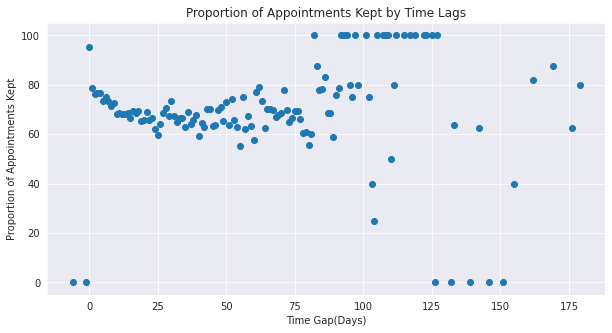

```python
fig = plt.figure(figsize=(10,5))
ax = fig.add_subplot()

ax.scatter(gaps, gap_props)
ax.set_xlabel('Time Gap(Days)')
ax.set_ylabel('Proportion of Appointments Kept')
ax.set_title('Proportion of Appointments Kept by Time Lags')
```

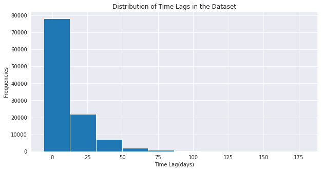

```python
# to begin, a visualization of age distribution could be useful
fig = plt.figure(figsize=(10,5))
ax = fig.add_subplot()

ax.hist(df['time_lag(days)'])
ax.set_xlabel('Time Lag(days)')
ax.set_ylabel('Frequencies')
ax.set_title('Distribution of Time Lags in the Dataset')
```

This histogram certianly makes things clearer. The larger time lags have too little frequencies to depict an accurate representation. The histogram shows that most appointments are done within two weeks, and much fewer are done after a month. The number of appointments decline onwards.

##### Generic Functions

Two generic functions will be defined to handle much of the rest of the operations. The columns typically have a feature with 0 or 1 to mark its absence or presence. For each of these, the proportions of appointments kept where the feature is present and where it is absent will be compared with bar plots.

```python
# Function to calculate and return values needed

def check_feature(feature_name):

    """ Since some features are represented by 0 for present and 1 for absent,
    the proportions of patients that show up can be derived with one function as thus:"""

    feature = len(df[df[feature_name]==1])
    feature_show = len(df[(df[feature_name]==1) & (df['no_show']=='No')])
    feature_noshow = feature - feature_show
    feature_show_prop = round((feature_show / feature)*100, 2)

    no_feature = len(df[df[feature_name]==0])
    no_feature_show = len(df[(df[feature_name]==0) & (df['no_show']=='No')])
    no_feature_noshow = no_feature - no_feature_show
    no_feature_show_prop = round((no_feature_show / no_feature)*100, 2)

    return feature, feature_show, feature_noshow, feature_show_prop, \
    no_feature, no_feature_show, no_feature_noshow, no_feature_show_prop
```

```python
def plot_feature(feature_name,\
                    feature, feature_show, feature_show_prop,\
                    no_feature, no_feature_show, no_feature_show_prop):

    """ A single function can also be used to plot those features"""

    fig = plt.figure(figsize=(10,5))
    gs = GridSpec(nrows=2, ncols=2)

    ax = fig.add_subplot(gs[:,0])
    X = np.arange(0,2)
    ax.bar(X-0.2, [feature, feature_show], 0.4, label=f'{feature_name.title()}')
    ax.bar(X+0.2, [no_feature, no_feature_show], 0.4, label=f'Not {feature_name.title()}')
    ax.set_xticks(X, ['Show Up', 'No Show'])
    ax.set_xlabel('Appointment Kept Status')
    ax.set_ylabel('Number of Patients')
    ax.set_title(f'Total Appointments by {feature_name.title()}')
    ax.legend()

    ax = fig.add_subplot(gs[:,1])
    ax.bar(x=[f'{feature_name.title()}', f'Not {feature_name.title()}'],
            height=[feature_show_prop, no_feature_show_prop])
    ax.set_xlabel(f'{feature_name.title()} Status')
    ax.set_ylabel('Proportion(%)')
    ax.set_title(f'Proportion of Patients that Show Up by {feature_name.title()}')
```

### Q5. Does disability prevent a patient from keeping appointments, and does this depend on number of disabilities?

> **TODO**
> - Use function to get numbers and proportions of handicap
> - Call function to plot bars
> - Generate a list of unique disability counts
> - Loop through the list to get proportion of appointments kept by disability counts
> - Visualize with a bar plot

```python
# generate values
handicap, handicap_show, handicap_noshow, handicap_show_prop,\
    no_handicap, no_handicap_show, no_handicap_noshow, no_handicap_show_prop\
        = check_feature('handicap')
```

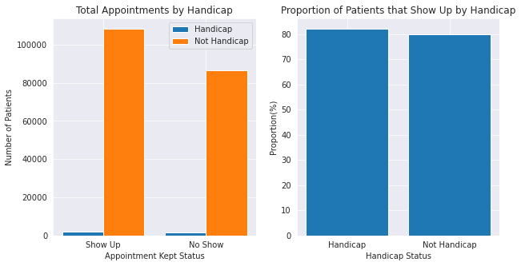

```python
# generate plot
plot_feature('handicap',\
    handicap, handicap_show, handicap_show_prop,\
    no_handicap, no_handicap_show, no_handicap_show_prop)
```

```python
# get unique disability counts and their corresponding proportions
disability_counts = df.handicap.unique()
the_props = []
for count in disability_counts:
    dis_count = len(df[df.handicap==count])
    dis_show_count = len(df[(df.handicap==count) & (df.no_show=='No')])
    the_props.append(round((dis_show_count/dis_count)*100, 2))
```

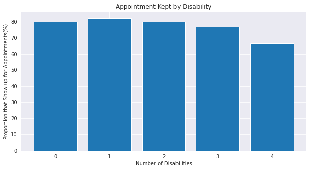

```python
# plot bar to compare
fig = plt.figure(figsize=(10,5))

ax = fig.add_subplot()
ax.bar(disability_counts, the_props)
ax.set_xlabel('Number of Disabilities')
ax.set_ylabel('Proportion that Show up for Appointments(%)')
ax.set_title('Appointment Kept by Disability')
```

There is certainly a clear trend here. People with just 1 disability are more likely to keep their appointments than those with no 0 disability. However, beyond that, the rate drops with increasing number of disabilities.

### Q6. Does the scholarship(a form of health insurance) enable people keep their appointments more?

> **TODO**
> - Use function to get numbers and proportions of handicap
> - Call function to plot bars
> - Further visualization with pie charts

```python
# generate values
schol, schol_show, schol_noshow, schol_show_prop,\
    no_schol, no_schol_show, no_schol_noshow, no_schol_show_prop\
        = check_feature('scholarship')
```

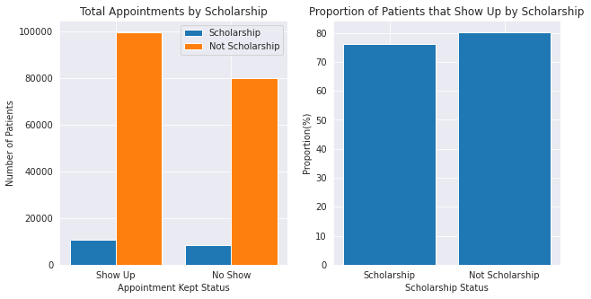

```python
plot_feature('scholarship',\
    schol, schol_show, schol_show_prop,\
    no_schol, no_schol_show, no_schol_show_prop)
```

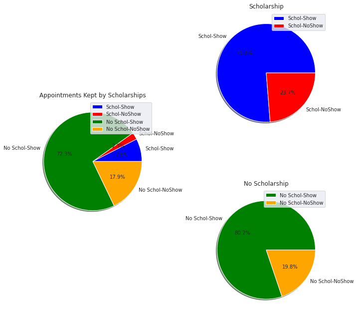

```python
# further visualization with pie charts

fig = plt.figure(figsize=(10,10))
gs = GridSpec(nrows=2, ncols=2)

ax = fig.add_subplot(gs[:,0])
ax.pie([schol_show, schol_noshow, no_schol_show, no_schol_noshow],
        labels=['Schol-Show', 'Schol-NoShow', 'No Schol-Show', 'No Schol-NoShow'],
        colors=['blue', 'red', 'green', 'orange'],
        shadow=True, autopct='%1.1f%%')
ax.legend()
ax.set_title("Appointments Kept by Scholarships")

ax = fig.add_subplot(gs[0,1])
ax.pie([schol_show, schol_noshow],
        labels=['Schol-Show', 'Schol-NoShow'],
        colors=['blue', 'red'],
        shadow=True, autopct='%1.1f%%')
ax.legend()
ax.set_title("Scholarship")

ax = fig.add_subplot(gs[1,1])
ax.pie([no_schol_show, no_schol_noshow],
        labels=['No Schol-Show', 'No Schol-NoShow'],
        colors=['green', 'orange'],
        shadow=True, autopct='%1.1f%%')
ax.legend()
ax.set_title("No Scholarship")

fig.tight_layout()
```

Against expectation, it appears that people without scholarships show up more often for their appointments than those without. This may be due to the fact that they spend their own money and would like to get the value?

### Q7. Does Hypertension make a patient keener to keep appointments?

> **TODO**
> - Use function to get numbers and proportions of hypertensive
> - Call function to plot bars

```python
hyper, hyper_show, hyper_noshow, hyper_show_prop,\
    no_hyper, no_hyper_show, no_hyper_noshow, no_hyper_show_prop\
        = check_feature('hypertension')
```

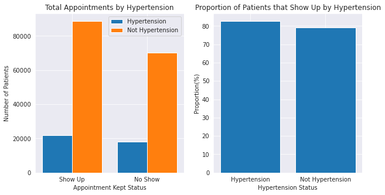

```python
plot_feature('hypertension',\
    hyper, hyper_show, hyper_show_prop,\
    no_hyper, no_hyper_show, no_hyper_show_prop)
```

Though most of the patients are not hypertensive, the plot shows that hypertensive patients are slightly more likely to keep their appoiments.

### Q8. How do diabetics fare with appointments?

> **TODO**
> - Use function to get numbers and proportions of diabetics
> - Call function to plot bars

```python
diab, diab_show, diab_noshow, diab_show_prop,\
    no_diab, no_diab_show, no_diab_noshow, no_diab_show_prop\
        = check_feature('diabetes')
```

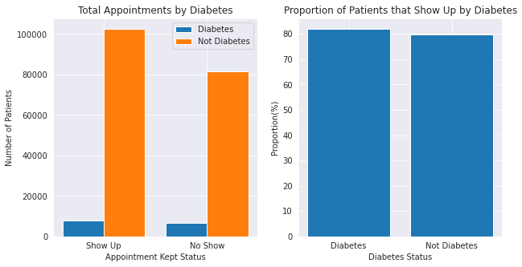

```python
plot_feature('diabetes',\
   diab, diab_show, diab_show_prop,\
    no_diab, no_diab_show, no_diab_show_prop)
```

Again, diabetics are slightly more likely to keep their appointments

### Q9. Does Alcoholism interfere with a patient's appointment-keeping?

> **TODO**
> - Use function to get numbers and proportions of alcoholics
> - Call function to plot bars

```python
alcoholic, alcoholic_show, alcoholic_noshow, alcoholic_show_prop,\
    no_alcoholic, no_alcoholic_show, no_alcoholic_noshow, no_alcoholic_show_prop\
        = check_feature('alcoholism')
```

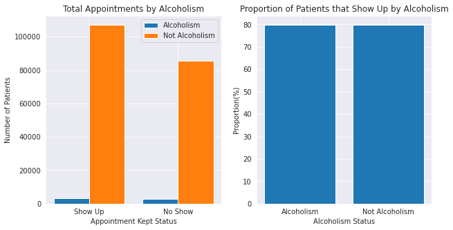

```python
plot_feature('alcoholism',\
   alcoholic, alcoholic_show, alcoholic_show_prop,\
    no_alcoholic, no_alcoholic_show, no_alcoholic_show_prop)
```

Though alcoholics are only a small fraction of the total, surprisingly, the alcoholics in this dataset do not lag in keeping their appointments. A computation actually shows **79.85%** of the alcoholics in this dataset show up, while **79.80%** of the non-alcoholics keep appointments.

### Q10. Are SMS reminders effective?

> **TODO**
> - Use function to get numbers and proportions of SMS reminders
> - Call function to plot bars

```python
sms, sms_show, sms_noshow, sms_show_prop,\
    no_sms, no_sms_show, no_sms_noshow, no_sms_show_prop\
        = check_feature('sms_received')
```

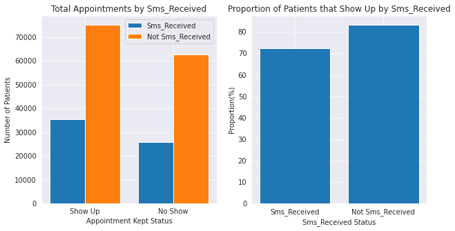

```python
plot_feature('sms_received',\
   sms, sms_show, sms_show_prop,\
    no_sms, no_sms_show, no_sms_show_prop)
```

# Conclusions

##### DISCLAIMER

This exploration is based only on a single dataset from a single region. While it does give some useful insights, it does not claim to be an absolute representation of trends all over the world or even in the locality from which the dataset has been collected.

> (c) EBENEZER MARADESA, 2022